# Notes de travaux dirigés

*Wilfrid Cariou*  
*UE de méthodes et pratiques numériques* *Ufr HHAA*  
*Université de Nantes* *2017*

Université de Nantes - UFR HHAA  
UE H44HI00 / H65HI01 v1.0 - 2017

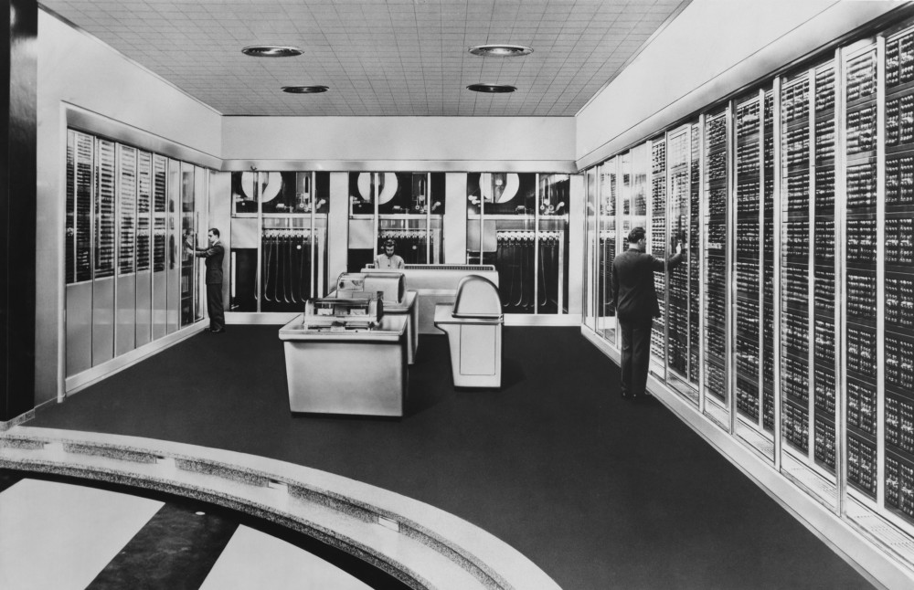

Mainframe

[figure not shown]

Le contenu de ce document est diffusé sous licence Creative Commons Attribution - Pas d’utilisation commerciale - Partage dans les mêmes conditions

# Découvrir les outils utilisés dans les travaux dirigés

## Tableur

Un tableur est un programme informatique applicatif interactif permettant de saisir, stocker, manipuler et d’analyser des données dans un tableau appelé feuille de calcul. À l’origine destiné au traitement automatisé des données financières, le tableur est dorénavant utilisés pour effectuer des tâches variées, de la gestion de bases de données simples à la production de graphiques, en passant par diverses analyses statistiques.  
Le terme français tableur est né en 1983 de la volonté de la Commission de l’informatique et des composants électroniques de créer une terminologie française en remplacement du terme anglo-saxon *Spreadsheet*.

[figure not shown]

Interface de LibO Calc

### Principales étapes de développement

Le concept de feuille de calcul computationnelle (*computerized spreadsheet*) est décrit en 1961 par Richard Mattesich, professeur à Berkeley puis implémenté sur différents *mainframes*.  
En 1969, une étape clé est franchie par la commercialisation du tableur LANPAR puis une seconde en 1978 par celle de tableur Visical qui connait un succès considérable notamment du fait de sa disponibilité sur un ordinateur personnel, l’Apple II. Visical est supplanté au début des années 80 par Lotus 123, plus performant puis à partir de 1984-1985 par Excel qui, développé sur la plate-forme Apple Macintosh, dispose d’une interface graphique.  
L’offre alternative libre et gratuite aux tableurs propriétaires se développe à partir de l’an 2000 (logiciels OpenOffice Calc et LibreOffice Calc). Plus récemment, les avancées du web, notamment l’architecture Ajax, rendent les feuilles de calcul disponibles en tant qu’applications Web (Google Sheet, 2006). Ces dernières, proches des applications de bureau en terme de fonctionnalités, facilitent le partage et l’édition collaborative.

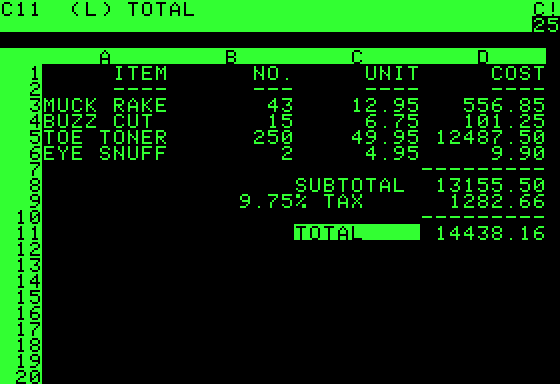

*Spreadsheet* (Visicalc)

### Principales composantes de l’interface

### Généralités

- Feuilles de calcul :  
  Une feuille de calcul se compose d’un tableau de cellules disposées en rangées et en colonnes et référencées. Les colonnes sont désignées par des lettres tandis que les rangées sont désignées par des nombres. Chaque cellule de la feuille de calcul possède une adresse ou référence associant une lettre et un nombre. Ce système de références cellulaires a été introduit dans VisiCalc et connu sous le nom de “notation A1”.
- Classeur :  
  Dans un tableur, plusieurs feuilles de calcul sont rassemblées pour former un classeur qui correspond à un fichier stockant l’ensemble des données.  
  Dans un classeur, les feuilles de calcul sont repérées par des onglets affichant leur nom et leur position au sein du classeur. L’adressage des cellules appartenant à différentes feuilles utilise la notation “nomfeuille!A1”.

> Dans LibO Calc, la gestion des feuilles s’effectue par le biais du *Menu Feuilles* ou des onglets situés dans la partie inférieure de l’interface.
- Cellules :  
  Les utilisateurs interagissent avec les feuilles de calcul principalement à travers les cellules. Une cellule peut être vide, contenir des données ou une formule.
- Formatage :  
  Les données stockées dans des cellules peuvent être affichées de différentes manières sans qu’elles ne se trouvent pour autant modifiées. Ainsi, il est possible…
  - d’ arrondir un développement décimal ;
  - d’ajouter de séparateurs des milliers ;
  - d’afficher en rouge de nombres négatifs ;
  - d’exprimer une proportion sous forme d’un pourcentage ;
  - d’afficher des dates dans différents formats.
> - Dans LibO Calc, le formatage d’une cellule ou d’une plage de cellules s’effectue par la commande **clic droit > Formater des cellules**.
> - Remarque importante : le formatage constitue une source d’erreur fréquente concernant les calculs portant sur des valeurs décimales.

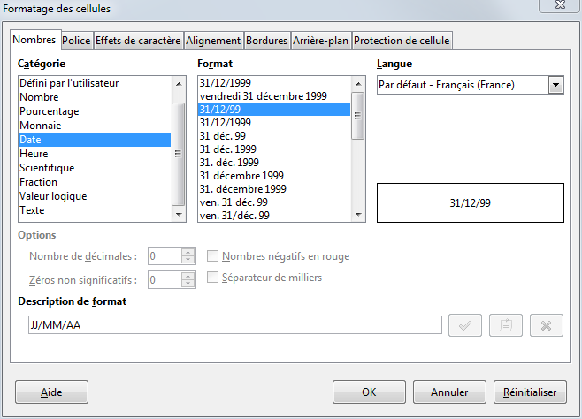

Fenêtre de formatage (LibO Calc)

- Formatage (ou mise en forme) conditionnelle :  
  L’apparence conférée aux cellules peut être établie selon une condition.
- Formule :  
  Une formule est une expression qui permet de manipuler les données présentes dans la feuille de calcul.
  - Une formule commence toujours par le signe `=`.
  - La validation d’une formule simple s’effectue par le biais de la touche **Entrée**. La validation de formules matricielles comme `FREQUENCE` s’effectue à l’aide de la combinaison de touches **Ctrl-maj-Entrée**.
- Fonction : Une fonction comporte une séquence d’instructions réalisant une tâche. Un logiciel comme LibreOffice Calc comprend plus de 400 fonctions. La plupart de ces fonctions sont destinées à être utilisées avec des données numériques mais un certain nombre s’appliquent à des des dates ou même des textes. Chaque fonction comporte des paramètres d’entrée que l’on nomme arguments.

> LibO Calc propose une liste organisée et commentée des fonctions *via* le **volet latéral (icone fx)** du logiciel .
- Calcul par référence :  
  La principale caractéristique des feuilles de calcul est la capacité d’une formule à se référer au contenu d’autres cellules. Dans l’exemple ci-dessous, la somme de 25 et 56 est calculée à l’aide de la formule `=SOMME(A1:A2)` qui fait référence aux adresses `A1` et `A2` correspondant aux cellules stockant les valeurs 25 et 56 .

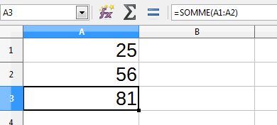

Exemple de calcul par référence (LibO Calc)

- Références relatives
  - Le tableur permet d’appliquer une formule à une liste de valeurs par recopie en utilisant un adressage désigné comme *relatif*.
  - Dans l’exemple ci-dessous la formule `=SOMME(A1:B1)` est relative à la ligne 1. En la recopiant vers “le bas” à l’aide de la poignée de recopie, la formule va automatiquement être convertie en `=SOMME(A2:B2)` jusqu’à `=SOMME(A4:B4)`.

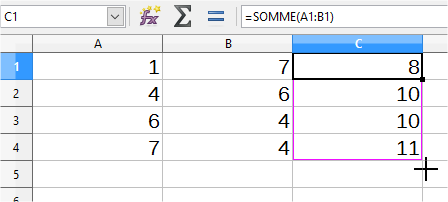

Recopie vers le bas (LibO Calc)

- Références absolues
  - Le référencement relatif lors d’une recopie peut être désactivé par l’utilisation du signe `$`. On parle alors d’adressage absolu.
  - L’exemple ci-dessous met en oeuvre le calcul de la fréquence des modalités ABCDEF par recopie.
  - A gauche, l’utilisation exclusive de références relatives conduit à des erreurs, la référence au total se décalant lors de la recopie.
  - A droite, le référence au total est bloquée par le signe `$` en `B$8` alors que la référence aux effectifs reste relative.

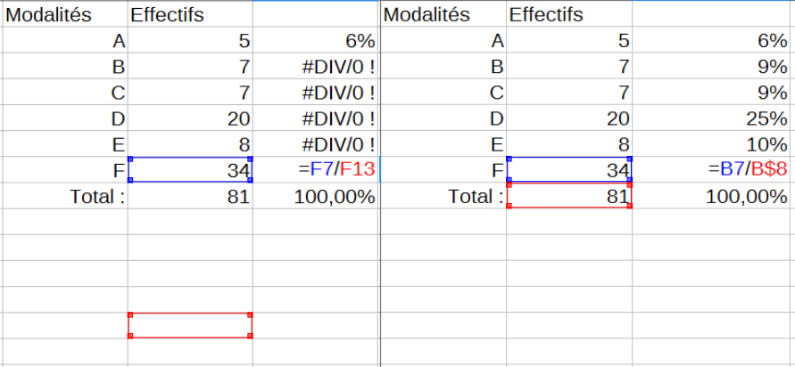

Recopie: comparaison entre l’utilisation de références relatives et absolues (LibO Calc)

> L’adressage relatif est l’adressage par défaut du tableur.

### Comparatif

| Désignation | Spécificités | Licences |
| --- | --- | --- |
| Libre Office Calc 5.2 | Importation et exportations flexible des csv et outils de filtrage avancés (expressions régulières). | gpl |
| Microsoft Excel 2007 | . | Propriétaire |
| Google sheets | Simplicité d’utilisation; sauvegarde automatique des documents en cours d’édition dans le Cloud (Google Drive); travail collaboratif en temps réel; importation et exportations dans les formats usuels;… | Propriétaire |

## Langage de programmation et environnement R

### Généralités

Langage de programmation et environnement spécialisé dans le traitement statistique des données sous licence libre et multi-plateformes. En pleine expansion (entrée de R dans les *big five* du classement de l’IEEE Spectrum 2016), R est devenu la “*Lingua franca* du traitement statistique et du traitement des données.” (Conférence UseR, 2013).  
Développé initialement en 1993 par Ross Ihaka et Robert Gentleman, il est principalement inspiré par les langages de programmation *Scheme* et *S* (Ihaka & Gentleman, 1996). Appartenant à la catégorie des langages interprétés, ilpermet une analyse interactive des données, sans phase de compilation.  
Conçu pour effacer la distinction entre utilisateurs et programmeurs, il se compose d’un socle sur lequel se greffe des *packages*, bibliothèque de fonctions implémentées par les utilisateurs et mises à disposition de tous.

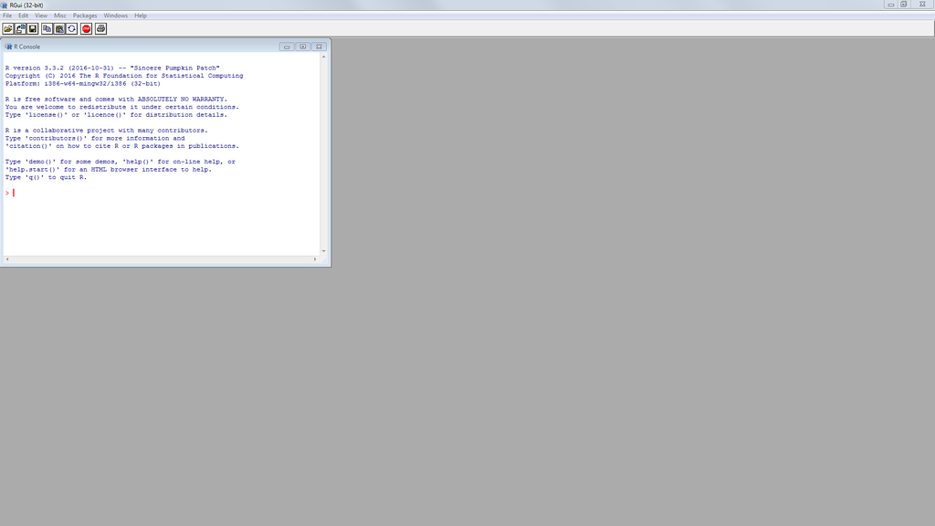

Graphical User Interface (R)

### Principales composantes de l’interface de R Studio

Le langage R possède une interface limitée qui n’a plus vocation à être directement utilisée. Nous utilisons en TD un logiciel assurant le rôle d’interface entre R et l’utilisateur : l’environnement de développement R Studio.

[figure not shown]

Environnement de développement (R Studio)

- **Code editing** (outils d’écriture de code)
- **Console** (interface de communication en ligne de commande)
- **Environment** (Importation des données & objets en mémoire)
- **Packages** (maquis des extensions)
- **Help** (aide)
- **Plots** (visualisation et enregistrement des sorties graphiques)
- **Files** (fichiers)

### Projets R Studio

Un projet R Studio est constitué d’un répertoire réunissant l’ensemble des fichiers utiles à la réalisation d’un projet avec R.

[figure not shown]

Exemple dossier local Rproj (Windows 7)

Un projet se crée à l’aide de la commande **Create New Project** accessible depuis le coin supérieur droit de R Studio.  
Un projet s’ouvre en par le biais du fichier **R.proj**.

Quand un projet est ouvert dans R Studio les actions suivantes sont notamment réalisés:  
* une nouvelle session de R est lancée ;  
* le répertoire de travail courant est réglé sur le répertoire du projet ;  
* le fichier **.rdata** chargé de contenir une sauvegarde des objets en mémoire est chargé;  
* les documents précédemment édités sont restaurés dans les onglets de R Studio.

### Quelques bases pour débuter en R

- Instructions  
  Une instruction dicte à l’ordinateur l’action nécessaire qu’il doit effectuer ( Instruction (informatique) (n.d.). In *Wikipedia.*). Les instructions ci-dessous sont appelées expressions. En informatique, une expression est un ensemble de valeurs, reliées par des opérateurs, et équivalent à une seule valeur. Elles sont saisies dans la console de R ou de R Studio à droite de l’invite (chevron `>`) et sont évaluées par la touche `Entrée`.

```r
# Exemples d'expressions

# Addition:
39 + 3.6
# Soustraction:
58 - 16
# Multiplication:
6 * 7
# Division:
8 / 2.5
# Reste de la division:
10 %% 3
# Partie entière de la division:
10 %/% 3
# Puissances:
5 ^ 3
# Priorités calculatoires:
((10 + 15) / 5) - 3 * 2
```

> Remarque importante: les résultats retournés ne sont pas conservés en mémoire.
- Instructions d’assignation de variables  
  Les variables sont des cases mémoire qui permettent de stocker des valeurs. Les variables les plus simples permettent de stocker des valeurs numériques ou des chaînes de caractères. Quand on créé une variable on parle de *déclaration* . Quand on lui donne une valeur, on parle *d’assignation*. Toute variable manipulée dans un programme est stockée en mémoire centrale. Cette mémoire est constituée d’octets qui sont identifiés de manière univoque par un numéro qu’on appelle *adresse*. C’est l’interpréteur, dans le cas de R, qui fait alors le lien entre l’identificateur d’une variable et son adresse en mémoire. En R, l’affectation se lit de droite à gauche; Les instructions situées à droite du signe flèche `<-` sont affectés à une variable désignée par un identificateur.

```r
x <-12      # assignation de la valeur 12 à la variable x
x           # évaluation et affichage du résultat

y <- 6 + 8   # assignation de l'adition de 6 et 8 à la variable y
y           # évaluation et affichage du résultat

rm()        # Remove All. suppression de l'ensemble des variables


x <- "Bonjour R" # Assignation d'une chaîne de caractères à la variable x
x  # évaluation et affichage du résultat

rm(x)       # Remove x: suppression de l'objet x
```

- Réaffectation  
  Il est permis de ré-affecter une nouvelle valeur à une même variable

```r
y <-  1500
y <- 1700
rm (y)
```

> Une variable possède à un moment donné une valeur et une seule.
- Séquences d’instructions

Les instructions sont les « briques de base » des programmes, dont l’assemblage dans un ordre précis conduit au résultat attendu.

```r
x <- 5.5
y <- 6 / 2

x + y
z <- x + 17 * y
rm()
```

- Utiliser les fonctions existantes  
  Une fonction comporte une séquence d’instructions réalisant une tâche. Une fonction est caractérisée par deux composantes :
  - son nom : c’est ce nom qui nous permettra de nous y référer, en programmation on dit *appeler une fonction*.
  - une liste d’arguments : ce sont les informations dont la fonction a besoin pour travailler et retourner un résultat. La syntaxe pour appeler une fonction est la suivante : `nom_de_la_fonction(arguments)`.

```r
sqrt (42) # Racine carrée de 42

x <- "bonjour"
y <- "R"

nchar(x) # Nombre de caractères de X
paste(x, y) # Concaténation de x et y

toupper(paste(x, y)) # Imbrication de fonctions (modif. de casse & concat.)
rm()
```

> La concaténation est le procédé qui permet de coller bout à bout différentes chaînes de caractères pour n’en faire plus qu’une seule. La casse renvoie aux notions de minuscules et majuscules.
- Les vecteurs  
  En R, le vecteur est un des éléments de base du langage. Un vecteur est une liste d’éléments étant tous du même type. Pour ces structures plus complexes, nous ne parlerons plus de variables comme précédemment mais d’objets. Les vecteurs peuvent être édifiés en combinant des éléments grâce à l’importante fonction `c()` (*combine*).

```r
v1 <- c(23, 5,8 , 33)       # Vecteur numérique, longueur 4

v2 <- c("hello","R")    # Vecteur de caractères, longueur 2

v3 <- c(TRUE, TRUE, FALSE)  # Vecteur logique

v4 <- 1:10         # Identique à  c(1,2,3,4,5,6,7,8,9,10)

v5 <- rep(1, 5)  #  Répétition du nombre 1 cinq fois

v6 <- rep(1:5, times = 2) # Répétition de  1,2,3,4,5  deux fois

v7 <- rep(1:10, each = 2) # Répétition de chaque nombre deux fois

v8 <- seq(1,20 , 2) # séquence de nombres entre 1 et 20, sauts de 2

rm()
```

## Systèmes d’informations géographiques

### Généralités sur les sig

- Un système d’information géographique (SIG) est un système informatique qui, à partir de cartes et de données tabulaires, permet de représenter, d’étudier et de gérer l’espace à différentes échelles et selon différentes couches thématiques. (Lévy & Lussault, 2013)
- Un SIG peut être défini comme un outil informatique permettant de stocker, de gérer, de traiter et de représenter l’information géographique. L’information est stockée et gérée dans une base de données géographiques, qui combine des données géométriques (localisation et forme) et thématiques.  
  Chaque thème d’information est représenté par une couche, ensemble d’objets élémentaires de même nature. Une couche associe la représentation cartographique des objets spatiaux et la table d’information statistique qui leur est associée.  
  L’information y est stockée et représentée au niveau du pixel (on est alors en mode raster) ou au niveau d’objets spatiaux élémentaires qui sont alors soit des points, des lignes ou des polygones (mode vecteur). La plupart des SIG permettent une combinaison de ces deux modes de gestion.  
  Les SIG permettent de croiser les informations contenues dans la base de données de différentes façons. D’une part les liens existant entre les caractéristiques géométriques et thématiques des objets permettent des sélections de sous ensembles à partir soit de requêtes portant sur les attributs statistiques, soit des requêtes dîtes spatiales à partir d’outils graphiques. D’autre part un certain nombre d’opérateurs géométriques ou topologiques permettent de travailler sur les objets spatiaux eux-mêmes qu’ils appartiennent ou non à une même couche. (Lena Sanders, s. d.)

### Qgis

QGIS est un logiciel SIG applicatif (système d’information géographique) libre multi plate-forme publié sous licence GPL dont le développement a débuté en 2002 (Qgis. (n.d.). In *Wikipedia.*).

[figure not shown]

Interface de Qgis 2.18

## Logiciel d’analyses de texte Voyant Tools

Voyant Tools est un environnement d’analyse de texte en ligne. Son interface est faîte pour être facilement utilisée tout en étant flexible et puissante. Il fait parti d’Hermeneuti.ca, un projet collaboratif qui a pour but de développer des outils d’analyse de texte. (« Voyant Tools — EduTech Wiki », s. d.).

## Gephi

Gephi est un logiciel open source utilisé pour visualiser des graphes (aussi appelés réseaux ou données relationnelles). Un graphe est un ensemble de points nommés *nœuds* (parfois sommets ou cellules) reliés par des traits (segments) ou flèches nommées *arêtes* (ou liens ou arcs). L’ensemble des arêtes entre nœuds forme une figure similaire à un réseau.  
Les arêtes peuvent être orientées (flèches) ou non orientées (traits). Si les arêtes sont orientées, la relation va dans un seul sens et est donc asymétrique, et le graphe lui-même est dit orienté. Sinon, si les arêtes sont non orientées, la relation va dans les deux sens et est symétrique, et le graphe est dit non orienté.

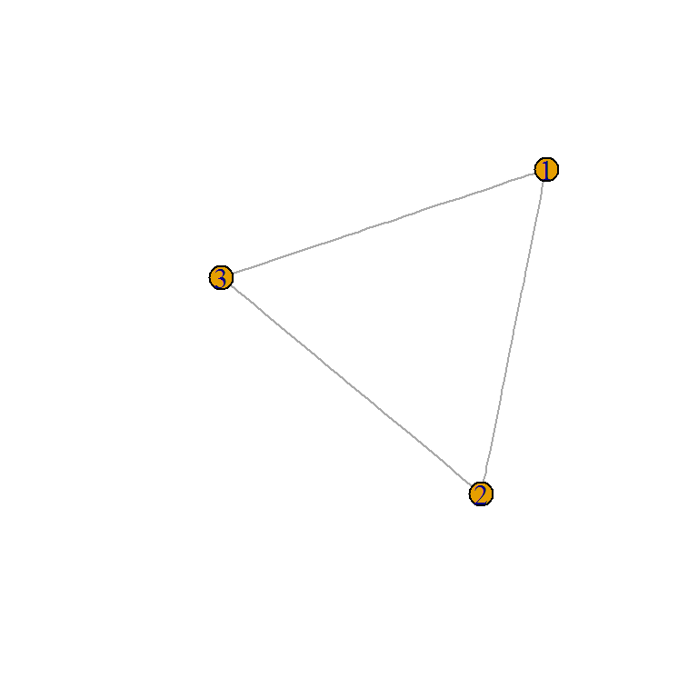

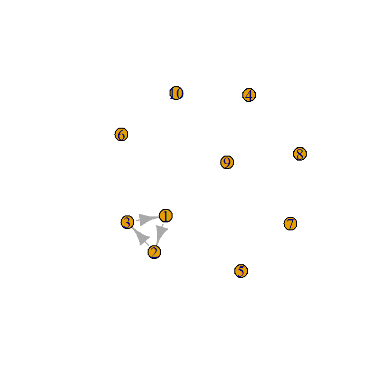

En mathématiques, l’ensemble des nœuds est le plus souvent noté V (vertices en anglais), tandis que E désigne l’ensemble des arêtes (edges en anglais). En théorie des graphes et en théorie des réseaux, les indicateurs de centralité sont des mesures censées capturer la notion vague d’importance dans un graphe, en identifiant les sommets les plus significatifs.  
Le terme de degré de centralité ou centralité de degré (« degree centrality ») est défini comme le nombre de liens incidents à un nœud (c’est-à-dire le nombre de voisins que possède un nœud). Dans le cas d’un réseau orienté, on définit habituellement deux mesures distinctes de la centralité de degré, à savoir le degré entrant et le degré sortant. En conséquence, degré entrant compte le nombre de liens dirigés vers le nœud et degré sortant est le nombre de liens qui dirigent le nœud vers d’autres. (Wikipedia)

## Utilitaires

- Editeurs de textes:  
  Notepad ++
- Logiciels d’archivage:  
  7 zip